# Driving Anxiety Phase I

Irina Benedyk

2025-11-09

Co-Authors: Gongda Yu, Ye Wang, Austin Angulo

# Young Adults Driving Anxiety

This is a report for **Phase** I of the research project developed in **TRAVLab** at CSEE Department of University at Buffalo during 2024-2025 academic year. Project was funded by ISTL, University at Buffalo.

## Key Take Aways

- Anxiety scores for *females are substantially higher than for males*, regardless of accident history; specific reasons for that are not clear, warranting future exploration
- There is *significant difference in anxiety scores between males who have been in an accident and those who have not* with the first group demonstrating lower anxiety score.

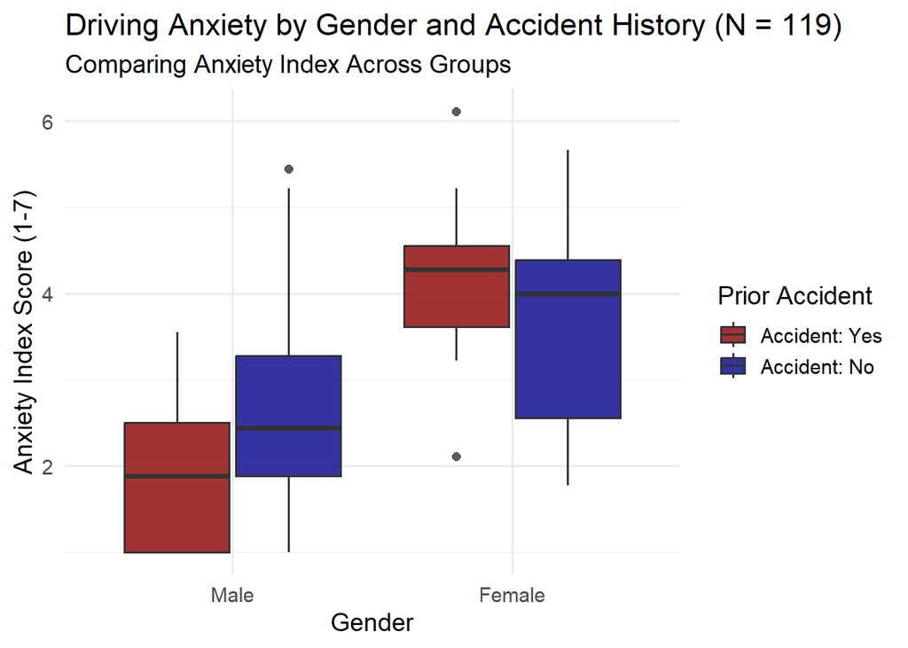

## Anxiety Index Summary

The `Anxiety_Index` was created as a composite score to quantify each participant’s overall driving anxiety by averaging their responses to nine specific survey questions: `x39`, `x40`, `x41`, `x42`, `x51`, `x52`, `x54`, `x55`, and `x56`.

First four questions assessed a range of anxious feelings and behaviors, asking participants to rate their agreement with statements like “I actively avoid driving on highways” (`x39`), “Driving in unfamiliar areas increases my anxiety” (`x40`), “I experience symptoms such as increased heart rate… when driving” (`x41`), and “While driving, I feel more indecisive than usual in my decisions” (`x42`).

Other questions, assessing experiences over the past year, used a frequency scale. All these questions used a 7-point scale where 1 represented the lowest level of anxiety (e.g., “Strongly Disagree” or “Never applies”) and 7 represented the highest level (e.g., “Strongly Agree” or “Always applies”). Statemetnts used in these questons are:

(x51) I avoided driving due to anxiety. (x52) I was frequently worried about encountering unsafe or dangerous drivers. (x53) Driving faster than 40 mph made me nervous. (x54) I had a constant fear of causing an accident. (x55) I constantly felt anxious about being blamed for a traffic conflict. (x56) My anxiety level increased when driving at night compared to during the day.

The resulting `Driving Anxiety Score (DAS)` is therefore a mean score between 1 and 7, where a higher value indicates a greater overall level of driving anxiety.

$$\text{DAS} = \frac{x39 + x40 + x41 + x42 + x51 + x52 + x54 + x55 +
x56}{9}$$
The bottom 25% of drivers had a DAS of 1.889 or less, while the top 25% had a score of 3.833 or higher, showing a significant split in the sample.

Descriptive Statistics for Anxiety Index (N = 119)

| Statistic | Value |
| --- | --- |
| Min. | 1.000 |
| 1st Qu. | 1.889 |
| Median | 2.667 |
| Mean | 2.830 |
| 3rd Qu. | 3.833 |
| Max. | 6.111 |

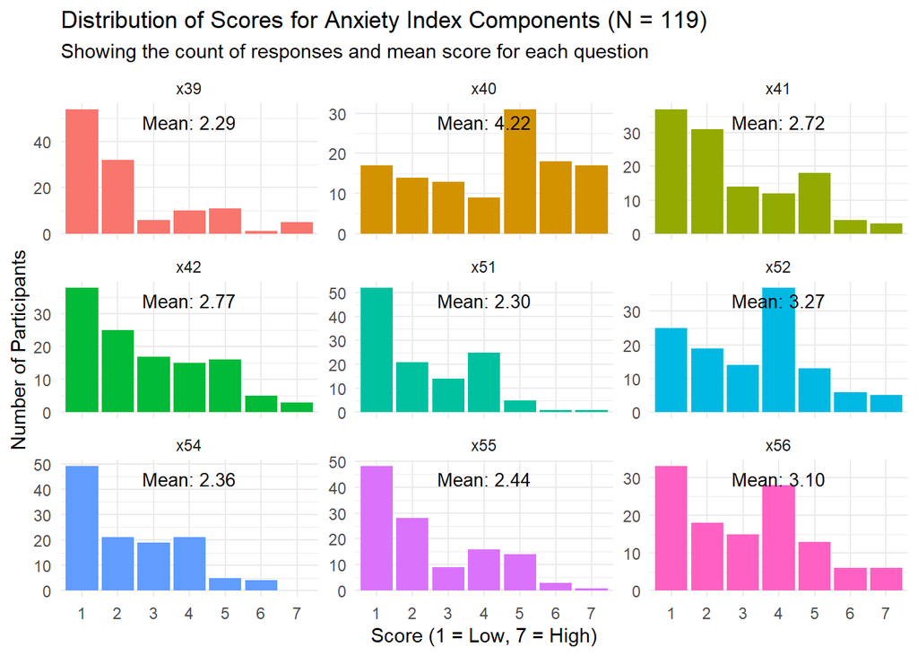

## Observations Regarding Driving Anxiety

*Unfamiliar Areas are a Key Stressor.*

```
The highest-rated anxiety item was "Driving in unfamiliar areas increases my anxiety" (x40), with a mean score of 4.22, indicating this is a common stressor for young drivers.
```

*Majority of Respondents don’t Report Anxiety as a Factor Impeding Driving.*

```
On average, participants disagreed with experiencing driving anxiety. The statement "I avoided driving due to anxiety" (x51) had a low mean score of 2.30.
```

*Fear of Causing an Accident is Low.*

```
Similarly, the statement "I had a constant fear of causing an accident" (x54) had a low mean of 2.36 (where 1="Never applies" and 7="Always applies").
```

## Data Facts

```
The dataset consists of young drivers. The average age is approximately 21 years old, with the entire sample ranging from 18 to 26. Every single participant (100%) reported holding a valid driver's license (being lisensed was an includion criterion).
```

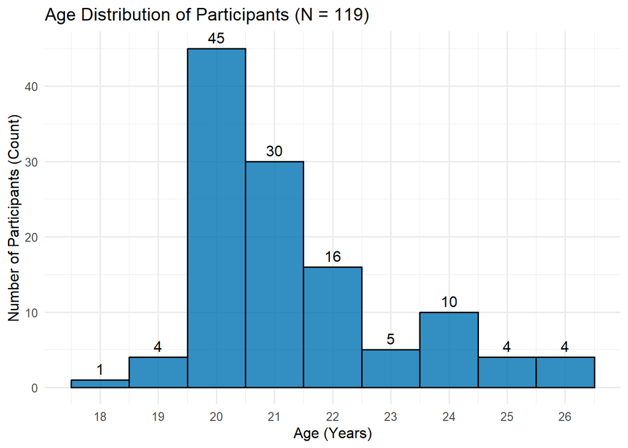

```
For sample group, driving is by far the most common way to commute to school or work. Over 73% indicated that "Driving" (variable x9) is their primary mode, followed by public transport (~14%) and micro-mobility (~10%).
```

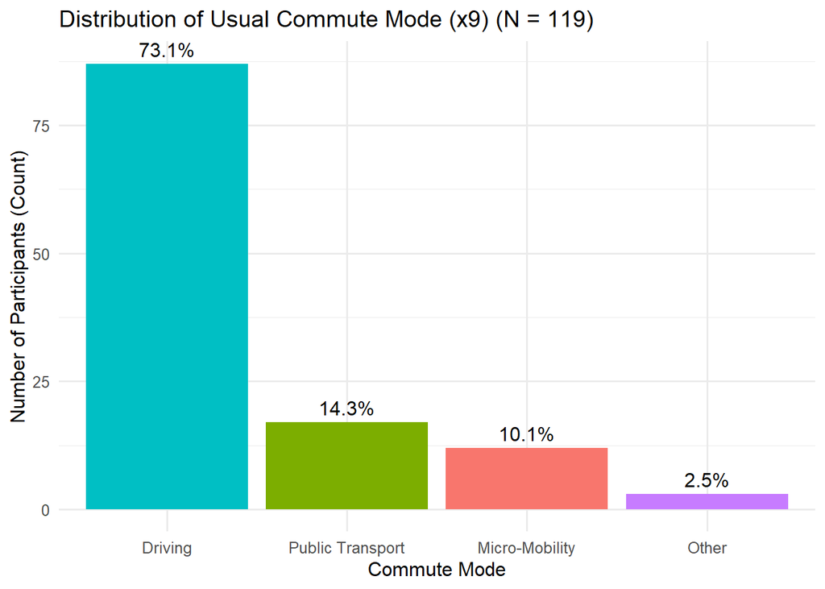

```
The study's participants are mostly male. About 69% of the sample identified as male (x4), with 30% identifying as female.
```

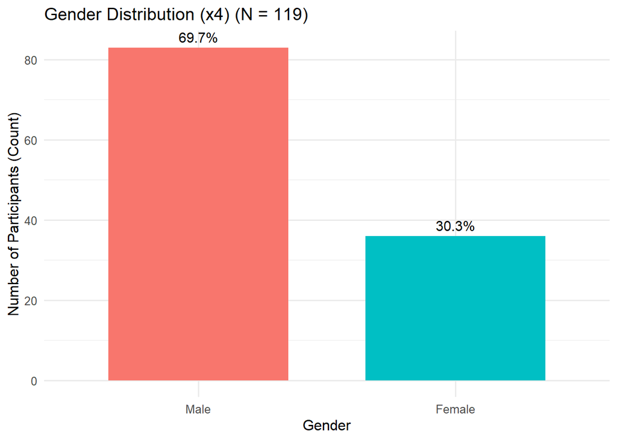

```
Participants are much more confident in their own driving skills than in others' creating "Confidence Gap". On a 7-point scale, average self-confidence (x30) was 5.35 ("Confident"), while average confidence in other drivers (x31) was only 3.04 ("Somewhat confident" / "Slightly confident").
```

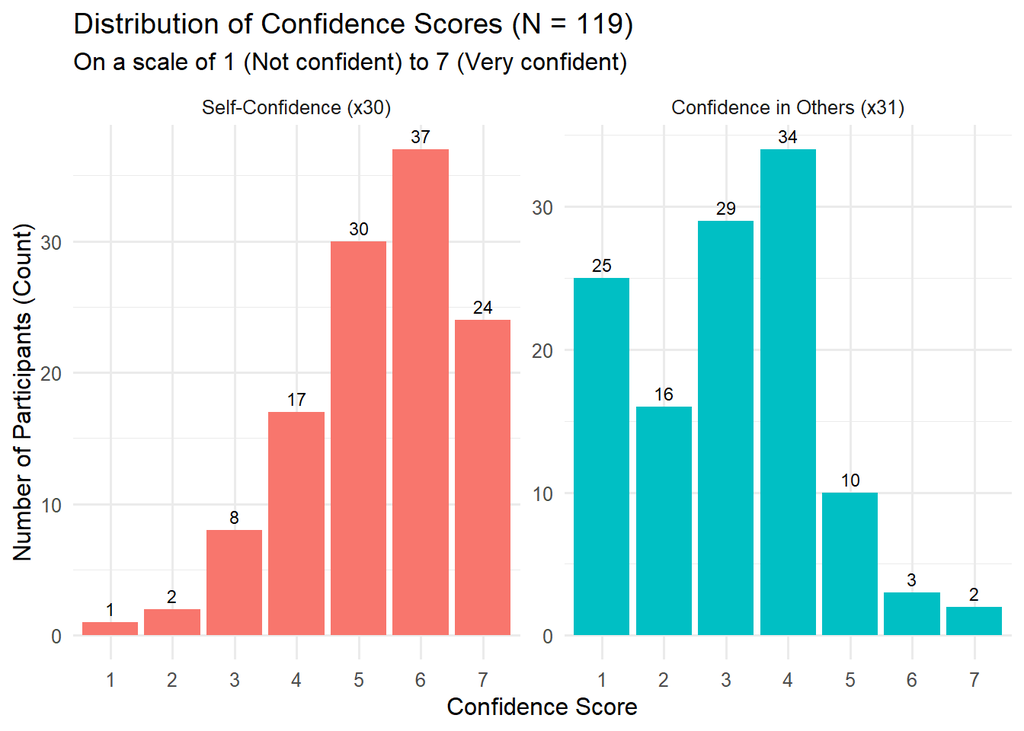

[output not shown]

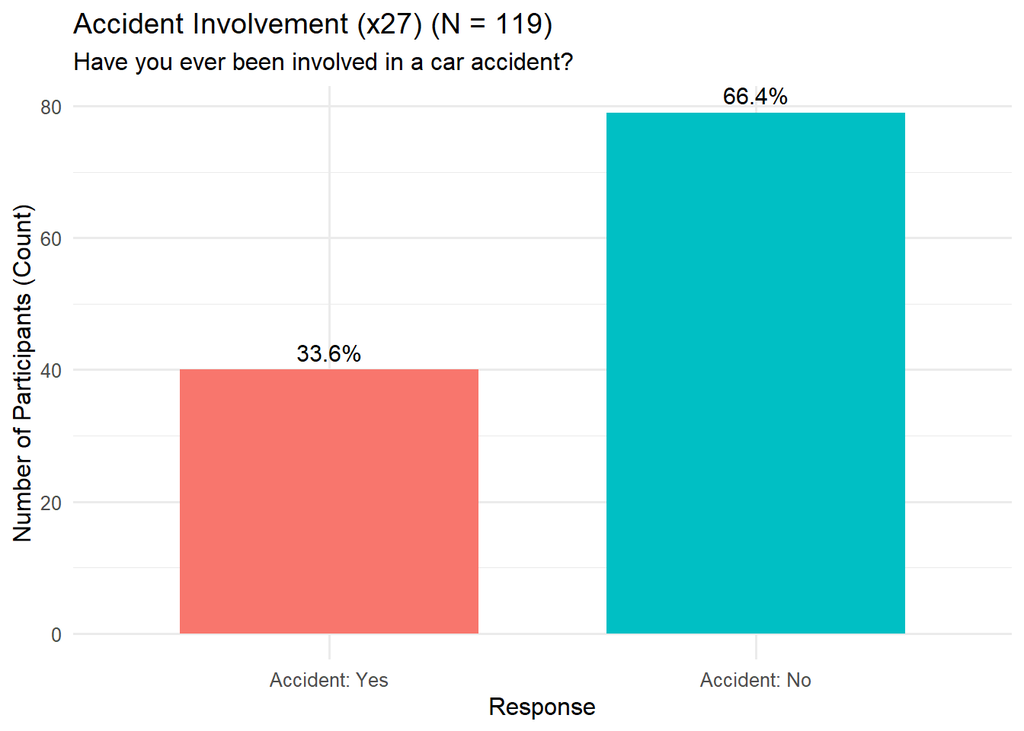

[output not shown]

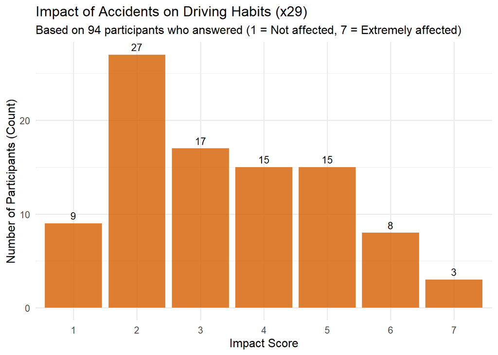

```
On average, participants lean toward disagreeing with the statement "Driving feels more like a burdensome responsibility than an enjoyable activity" (x99). The mean score was 3.19 (where 1="Strongly Disagree" and 7="Strongly Agree").
```

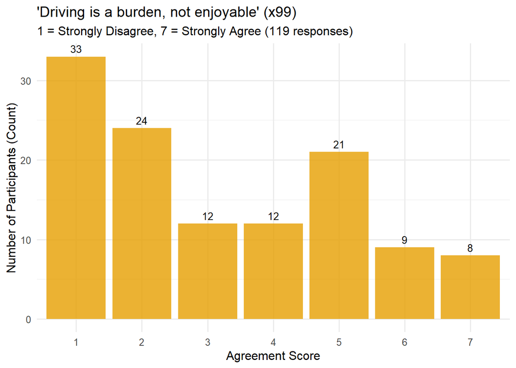

## Characteristics of Drivers with Higher Anxiety

To find out what makes high-anxiety drivers different, we have compared the *Top 25%* most anxious drivers (High Anxiety Group) to the *Bottom 25%* least anxious drivers (Low Anxiety Group). The analysis revealed several strong characteristics:

```
On a 7-point scale, the high-anxiety group's average self-confidence (x30) was 4.07 ("Somewhat confident"), while the low-anxiety group's was 6.33 ("Very confident") demostrating *significantly lower self-cofidence of HAG*.
```

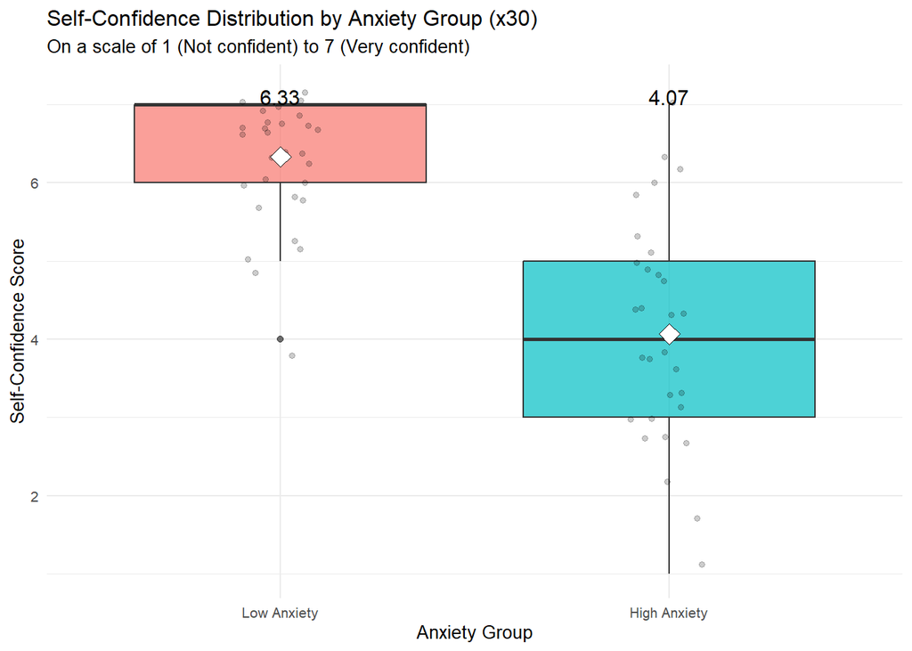

[output not shown]

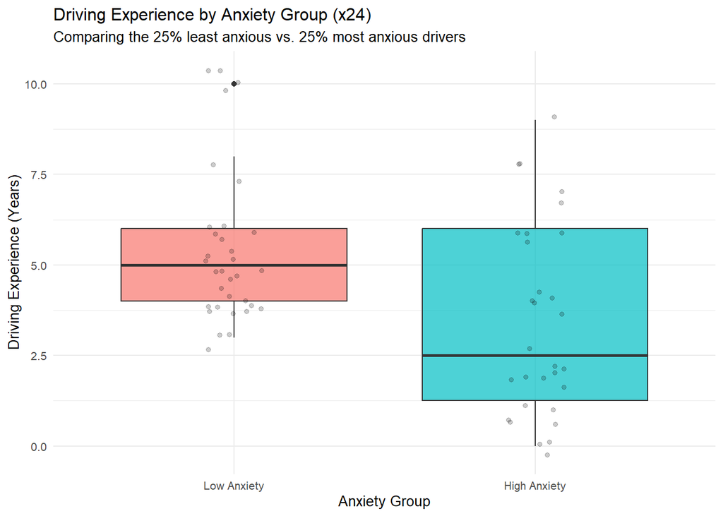

[output not shown]

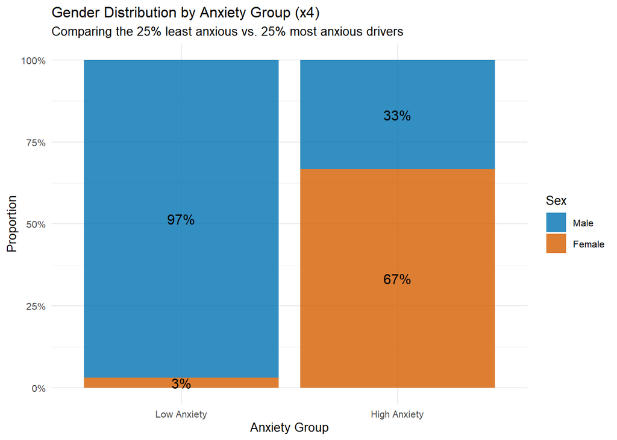

```
Less Likely to Have Been in an Accident: Interestingly, the high-anxiety group was less likely to have been in an accident (x27). Only 23% of the high-anxiety group reported being in an accident, compared to 48% of the low-anxiety group.
```

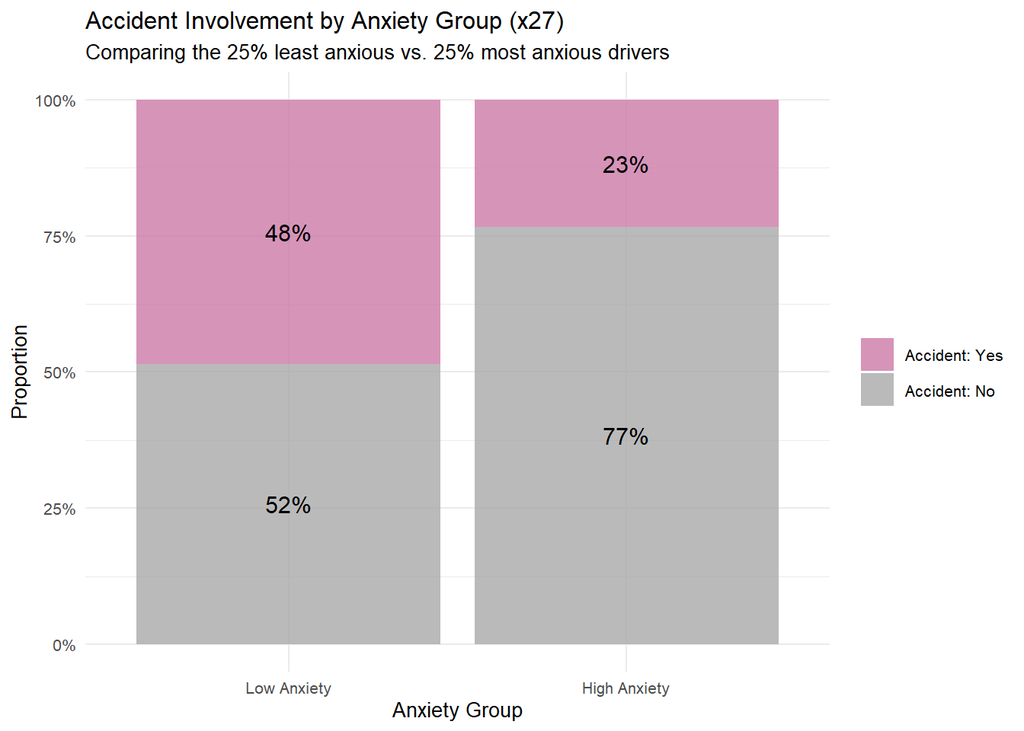

```
Slightly Older: The high-anxiety group was, on average, slightly older (22.1 years vs. 21.3 years) despite having shorter driving experience indicating of possible external covariate that impacted both factors (being anxtious while driving and later acquisition of DL).
```

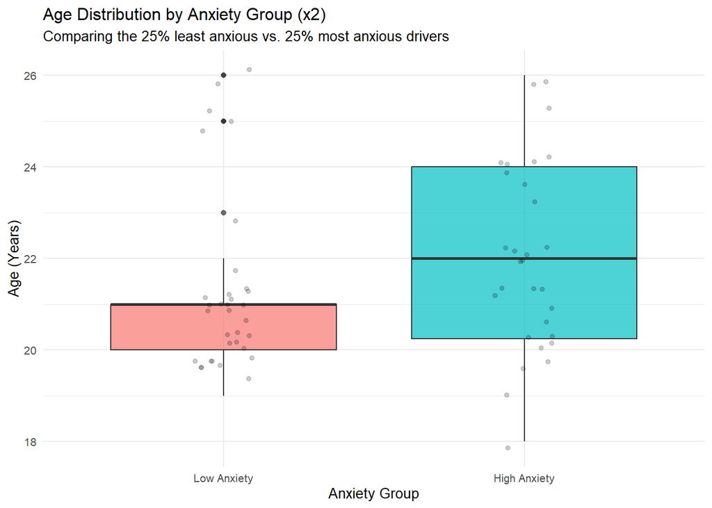

[output not shown]

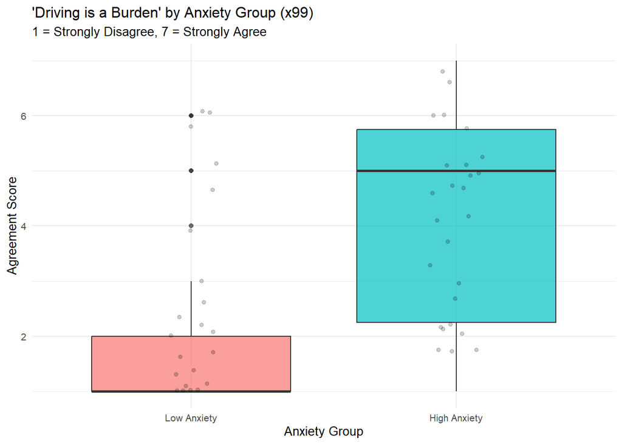

[output not shown]

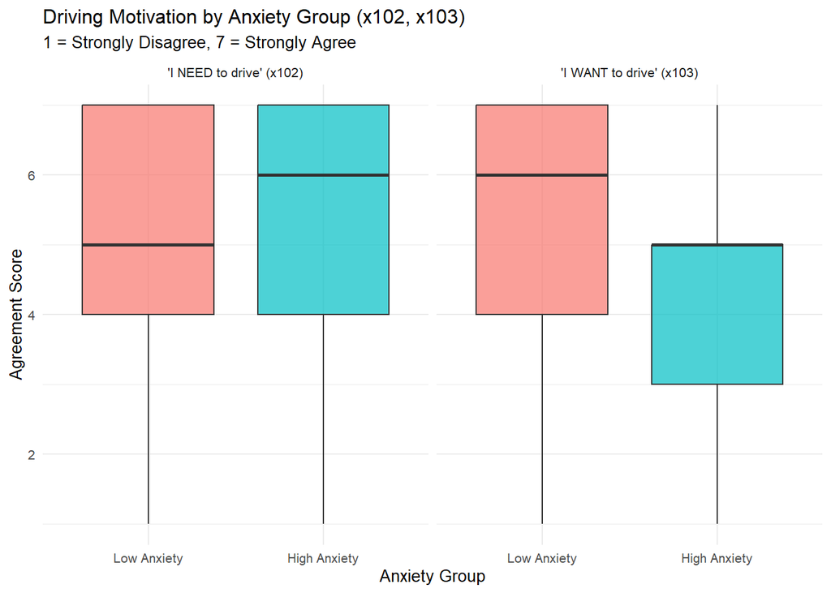

```
When asked how they decide who drives when with friends or family (x67), the groups' preferences were inverted.

- High Anxiety: 33% said "I usually let friends or family drive" (Option 1).

- Low Anxiety: Only 9% chose this, with 39% stating "I prefer to drive myself" (Option 2).
```

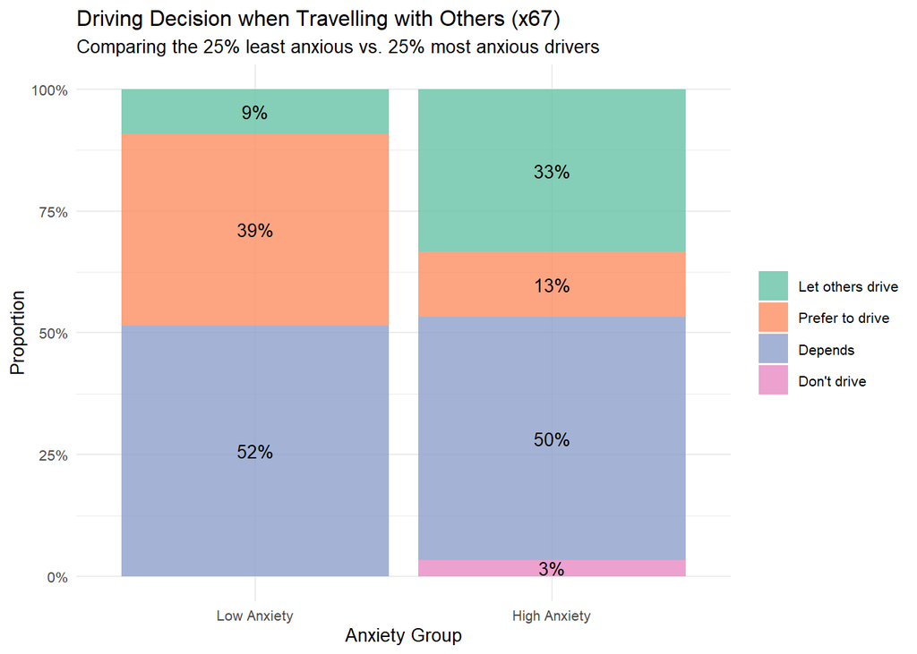

```
The high-anxiety group reported "Rarely" to "Sometimes" (mean score of 3.33) engaging in specific activities to alleviate anxiety before driving, such as listening to music or deep breathing (X60). The low-anxiety group reported "Never" (mean score of 1.18).
```

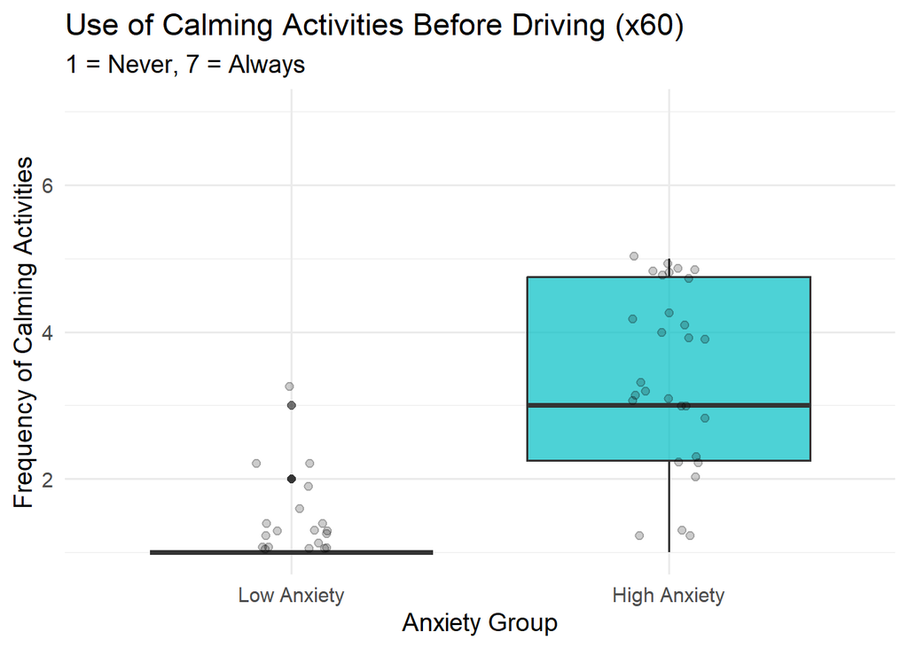

```
When asked if they think additional training could improve their driving confidence (x66), 67% of the high-anxiety group answered "Yes." In contrast, the low-anxiety group was split, with 54% answering "No," suggesting they feel their confidence is already sufficient.
```

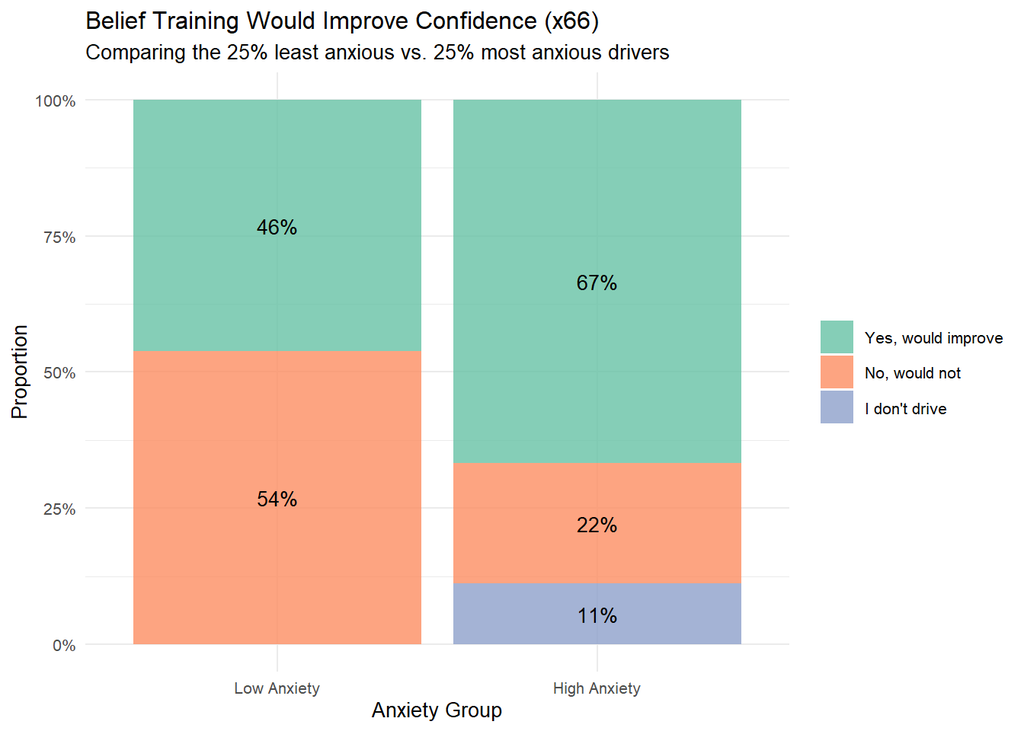

## Gender, Prior Accident Experience, and Driving Anxiety Score

When analyzing the interplay between gender, prior accidents, and driving anxiety, a clear pattern emerges where gender is the dominant factor. Visually, the anxiety scores for *females are substantially higher than for males*, regardless of accident history. While one might expect prior accident involvement to significantly increase anxiety, the statistical analysis shows this is not an observed effect in this data set. There is *significant difference in anxiety scores between males who have been in an accident and those who have not* with the first group demonstrating lower anxiety score. For females, the difference is not statistically significant, though *the trend suggests females with accident experience have slightly higher anxiety*. The most statistically significant divide, by far, is between genders, with **females reporting significantly higher anxiety scores than males overall**.

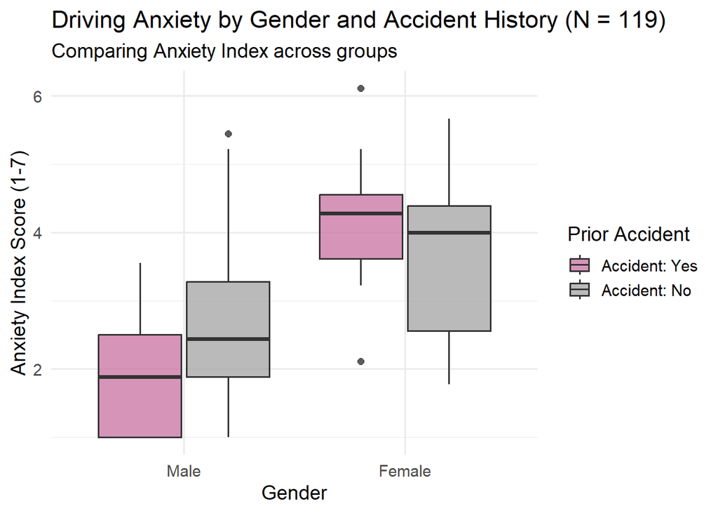

Statistical Comparison of Anxiety Index Scores

[output not shown]